# Properties of the Perfect Pop Song

Brooke Conley

5/17/2020

## Introduction

The way we listen to music today is very different from the way we listened to music 50 years ago. We have substantially more freedom when it comes to selecting which songs we want to listen to and when, and this fact, among many others, has influenced the way that music is produced. Before streaming services like Spotify and Apple music came around, if you wanted to have constant access to a song, it would likely cost you about a dollar. For the price of one (undiscounted) Spotify subscription, you could listen to a grand total of ten new songs per month. With Spotify, if you played new music continuously for every minute of the month, you could listen to approximately 14,600 new songs (assuming an average song is three minutes long and there is no repetition). While this example does not represent conventional use, in the most extreme case, you could save $14,590 in one month by purchasing a Spotify subscription in 2020 instead of individually purchasing each song through the iTunes store circa 2010. This situation is made even more unrealistic by the fact that the iPod you had in 2010 had enough store for only 7,000 songs, given that you paid extra for the 32 GB model. To say the least, times have changed.

Today’s producers have made considerable changes to their methods to adapt to this.

```r
tunes_tab <- read_csv("ultimate-spotify-tracks-db/SpotifyFeatures.csv")
tunes_tab <- na.omit(tunes_tab)
tunes_tab <- tunes_tab[!duplicated(tunes_tab$track_id),]
tunes_tab$time_signature <- NULL
tunes_tab <- tunes_tab[,c(1, 2, 3, 4, 11, 14, 5, 6, 7, 8, 9, 10, 12, 13)]
tunes_tab
```

```
## # A tibble: 176,774 x 14
##    genre artist_name track_name track_id key   mode  popularity acousticness
##    <chr> <chr>       <chr>      <chr>    <chr> <chr>      <dbl>        <dbl>
##  1 Movie Henri Salv~ C'est bea~ 0BRjO6g~ C#    Major          0      0.611
##  2 Movie Martin & l~ Perdu d'a~ 0BjC1Nf~ F#    Minor          1      0.246
##  3 Movie Joseph Wil~ Don't Let~ 0CoSDzo~ C     Minor          3      0.952
##  4 Movie Henri Salv~ Dis-moi M~ 0Gc6TVm~ C#    Major          0      0.703
##  5 Movie Fabien Nat~ Ouverture  0IuslXp~ F     Major          4      0.95
##  6 Movie Henri Salv~ Le petit ~ 0Mf1jKa~ C#    Major          0      0.749
##  7 Movie Martin & l~ Premières~ 0NUiKYR~ C#    Major          2      0.344
##  8 Movie Laura Mayne Let Me Le~ 0PbIF9Y~ F#    Major         15      0.939
##  9 Movie Chorus      Helka      0ST6uPf~ C     Major          0      0.00104
## 10 Movie Le Club de~ Les bisou~ 0VSqZ3K~ G     Major         10      0.319
## # ... with 176,764 more rows, and 6 more variables: danceability <dbl>,
## #   duration_ms <dbl>, energy <dbl>, instrumentalness <dbl>, liveness <dbl>,
## #   loudness <dbl>
```

[figure not shown]

```r
set.seed(1234)

tunes_tab[sample(nrow(tunes_tab), 100), ] %>%
  ggplot(aes(x=popularity, y = loudness))+
  geom_point()+
  theme_minimal()+
  geom_smooth()+
  labs(x="Popularity", y="Danceability", title="not sure")
```

```r
tunes_tab %>%
  group_by(genre) %>%
  count(popularity) %>%
  knitr::kable()
```

[output not shown]

[output cut: 1688 more lines]

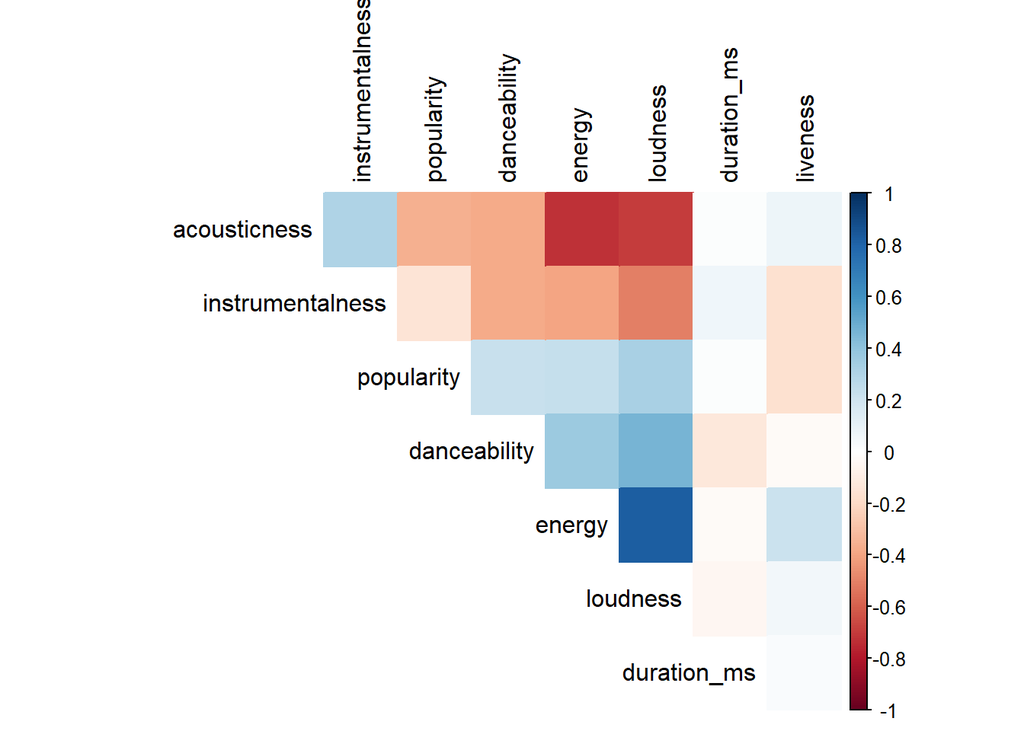

```r
feature_names <- names(tunes_tab)[7:14]
tunes_tab %>%
  select(feature_names) %>%
  scale() %>%
  cor() %>%
  corrplot::corrplot(method = 'color',
                     order = 'hclust',
                     type = 'upper',
                     diag = FALSE,
                     tl.col = 'black',

                     number.cex = 0.6,

                     main = 'Audio Feature Correlation
                     ')
```

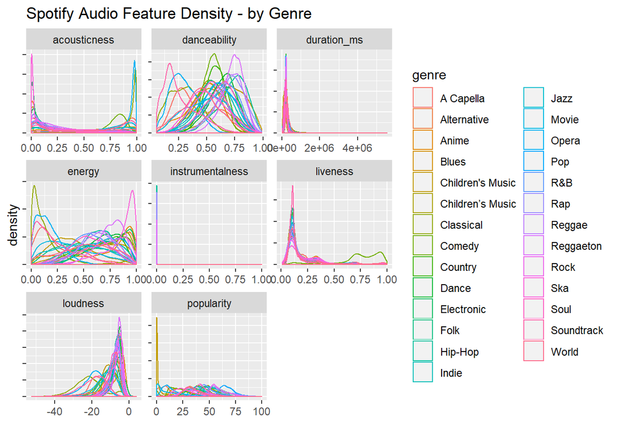

```r
tunes_tab %>%
  select(c('genre', feature_names)) %>%
  pivot_longer(cols = feature_names) %>%
  ggplot(aes(x = value)) +
  geom_density(aes(color = genre), alpha = 0.5) +
  facet_wrap(~name, ncol = 3, scales = 'free') +
  labs(title = 'Spotify Audio Feature Density - by Genre',
       x = '', y = 'density') +
  theme(axis.text.y = element_blank())
```

## The Question: What do listeners want to hear, and how does it vary by genre?

## Parsing and Data Management

## Exploratory Data Analysis

## Hypothesis Testing and Machine Learning